# Problem Set 4

Author

Aidan Dugan

Published

November 20, 2026

[output not shown]

**GitHub repo:** https://github.com/adugan10/ec422_ps4_dugan

## ARIMA vs. ETS

### 2.1. Monthly liquor store sales

**2.1a** I looked at monthly U.S. sales at beer, wine, and liquor stores from January 1992 through December 2019. The sales numbers are in millions of dollars and haven’t been adjusted for seasonality. Every month is accounted for, giving a complete set of 336 months. I stopped the sample at the end of 2019 to avoid the wild swings during the pandemic. [FRED series](https://fred.stlouisfed.org/series/MRTSSM4453USN)

```r
liquor_raw <- read_csv(
  "data/MRTSSM4453USN.csv", na = ".",
  col_types = cols(
    observation_date = col_date(format = "%Y-%m-%d"),
    MRTSSM4453USN = col_double()
  )
)

liquor <- liquor_raw |>
  transmute(
    Month = yearmonth(observation_date),
    sales = MRTSSM4453USN
  ) |>
  as_tsibble(index = Month) |>
  filter(
    Month >= yearmonth("1992 Jan"),
    Month <= yearmonth("2019 Dec")
  )

has_gaps(liquor)
```

```
# A tibble: 1 × 1
  .gaps
  <lgl>
1 FALSE
```

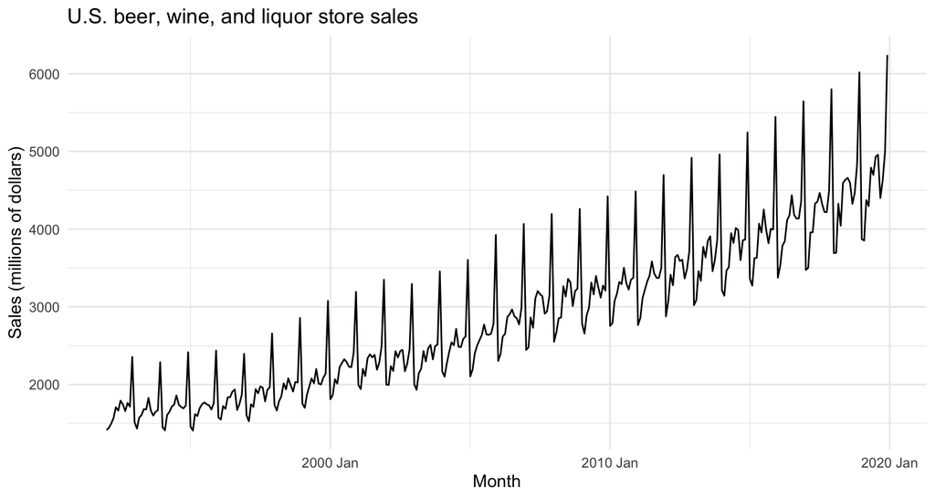

```r
autoplot(liquor, sales) +
  labs(
    title = "U.S. beer, wine, and liquor store sales",
    x = "Month",
    y = "Sales (millions of dollars)"
  )
```

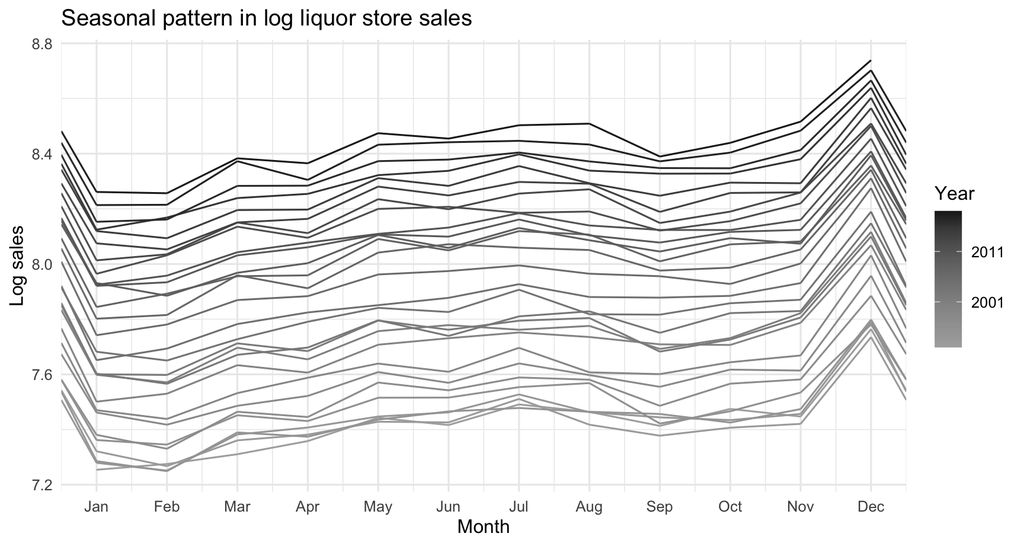

```r
gg_season(
  liquor, log(sales),
  pal = gray.colors(9, start = 0.68, end = 0.12)
) +
  labs(
    title = "Seasonal pattern in log liquor store sales",
    x = "Month",
    y = "Log sales",
    colour = "Year"
  )
```

**2.1b** Sales usually go up over time. December generally stands out as the big peak, and then things drop off sharply in January and February. There’s also a smaller bump in late spring and summer. The December spike gets bigger in dollar terms as sales grow, suggesting that the seasonal swings are proportional to the level of sales. Taking logs helps stabilize those swings across years.

### 2.2. Model selection and residuals

```r
liquor_fit <- readRDS("results/liquor_fit.rds")

liquor_fit |> select(arima) |> report()
```

```
Series: sales
Model: ARIMA(1,0,2)(2,1,1)[12] w/ drift
Transformation: log(sales)

Coefficients:
         ar1      ma1     ma2    sar1     sar2     sma1  constant
      0.8948  -0.7374  0.2477  0.3679  -0.2334  -0.8845    0.0036
s.e.  0.0355   0.0697  0.0623  0.0668   0.0665   0.0468    0.0001

sigma^2 estimated as 0.0005469:  log likelihood=752.43
AIC=-1488.85   AICc=-1488.4   BIC=-1458.61
```

```r
liquor_fit |> select(ets) |> report()
```

```
Series: sales
Model: ETS(A,A,A)
Transformation: log(sales)
  Smoothing parameters:
    alpha = 0.3296099
    beta  = 0.007560263
    gamma = 0.0001765132

  Initial states:
     l[0]         b[0]      s[0]      s[-1]        s[-2]       s[-3]      s[-4]
 7.412219 0.0007608238 0.3263441 0.03153301 -0.004849389 -0.03530501 0.02512163
      s[-5]      s[-6]      s[-7]       s[-8]      s[-9]     s[-10]     s[-11]
 0.05558624 0.01219515 0.02503206 -0.06088935 -0.0607952 -0.1578065 -0.1561667

  sigma^2:  7e-04

      AIC      AICc       BIC
-489.1517 -487.2272 -424.2608
```

**2.2a** The automatically selected ARIMA model was **ARIMA(1,0,2)(2,1,1)[12] with drift**. It uses one seasonal difference, so it subtracts log sales from the same month a year before. There are no ordinary differences. The automatically selected ETS model was ETS(A,A,A), which means it uses additive errors, an additive trend, and additive seasonality on the log scale.

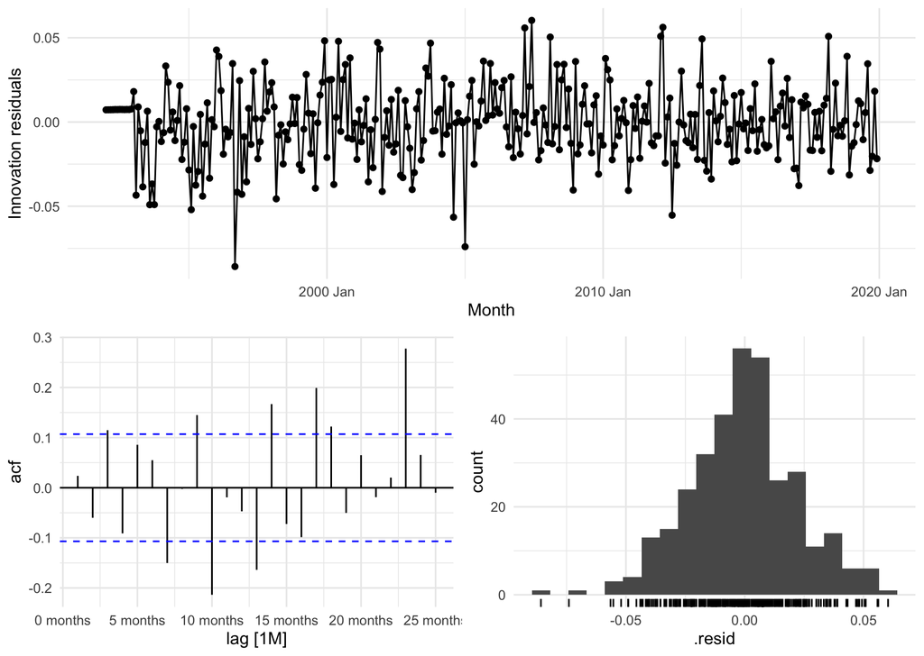

```r
liquor_fit |>
  select(arima) |>
  gg_tsresiduals()
```

```r
diag_arima <- readRDS("results/liquor_diagnostics.rds")

diag_arima$ljung_box |>
  transmute(
    Lag = 24L,
    `AR and MA terms` = diag_arima$dof,
    `Test df` = 24L - diag_arima$dof,
    `Ljung–Box Q` = lb_stat,
    `p-value` = format_p(lb_pvalue)
  ) |>
  knitr::kable(digits = 3)
```

| Lag | AR and MA terms | Test df | Ljung–Box Q | p-value |
| --- | --- | --- | --- | --- |
| 24 | 6 | 18 | 120.39 | 3.543e-17 |

**2.2b** There were six estimated AR and MA coefficients, $1+2+2+1=6$. With 24 lags, the Ljung–Box test ends up with 18 degrees of freedom. The residuals bounce around zero, but a few autocorrelations go past the reference lines. The test statistic was **120.39**, with $p \approx 3.54\times10^{-17}$. So, there’s still some serial correlation in the residuals. That’s why I’d look at how the model does on months it hasn’t seen yet.